# Case Study

Jonathan Franks

February 19, 2018

## Introduction

### Data Manipulation

It is necessary to begin this analyses by cleanning up the data. First we will import the data sets and create an merged collection for future use.

```r
library("plyr")
```

```r
library("ggplot2")
Breweries <- read.csv(file="Data/Breweries.csv", header= TRUE)
Beers <- read.csv(file="Data/Beers.csv", header= TRUE)
colnames(Breweries)[colnames(Breweries)=="Name"] <- "Brewery Name"
colnames(Beers)[colnames(Beers)=="Name"] <- "Beer Name"
colnames(Breweries)[colnames(Breweries)=="Brew_ID"] <- "Brewery_id"

BB <-merge(Breweries,Beers,by="Brewery_id")
```

### Merged Data Set Verification

It is important to verify the data after merging to ensure nothing went wrong during the process and to catch any mistakes that may have been made.

```r
head(BB,6)
```

```
##   Brewery_id       Brewery Name        City State     Beer Name Beer_ID
## 1          1 NorthGate Brewing  Minneapolis    MN       Pumpion    2689
## 2          1 NorthGate Brewing  Minneapolis    MN    Stronghold    2688
## 3          1 NorthGate Brewing  Minneapolis    MN   Parapet ESB    2687
## 4          1 NorthGate Brewing  Minneapolis    MN  Get Together    2692
## 5          1 NorthGate Brewing  Minneapolis    MN Maggie's Leap    2691
## 6          1 NorthGate Brewing  Minneapolis    MN    Wall's End    2690
##     ABV IBU                               Style Ounces
## 1 0.060  38                         Pumpkin Ale     16
## 2 0.060  25                     American Porter     16
## 3 0.056  47 Extra Special / Strong Bitter (ESB)     16
## 4 0.045  50                        American IPA     16
## 5 0.049  26                  Milk / Sweet Stout     16
## 6 0.048  19                   English Brown Ale     16
```

```r
tail(BB, 6)
```

```
##      Brewery_id                  Brewery Name          City State
## 2405        556         Ukiah Brewing Company         Ukiah    CA
## 2406        557       Butternuts Beer and Ale Garrattsville    NY
## 2407        557       Butternuts Beer and Ale Garrattsville    NY
## 2408        557       Butternuts Beer and Ale Garrattsville    NY
## 2409        557       Butternuts Beer and Ale Garrattsville    NY
## 2410        558 Sleeping Lady Brewing Company     Anchorage    AK
##                      Beer Name Beer_ID   ABV IBU                   Style
## 2405             Pilsner Ukiah      98 0.055  NA         German Pilsener
## 2406         Porkslap Pale Ale      49 0.043  NA American Pale Ale (APA)
## 2407           Snapperhead IPA      51 0.068  NA            American IPA
## 2408         Moo Thunder Stout      50 0.049  NA      Milk / Sweet Stout
## 2409  Heinnieweisse Weissebier      52 0.049  NA              Hefeweizen
## 2410 Urban Wilderness Pale Ale      30 0.049  NA        English Pale Ale
##      Ounces
## 2405     12
## 2406     12
## 2407     12
## 2408     12
## 2409     12
## 2410     12
```

### Breweries Per State

From the data below we can find the five states with the most breweries and the five states with the least breweries. Comparativerly we have the highest breweries per state, Colorado with 47 breweries and DC the state with the fewest at 1 brewery.

```r
StateBrew <- count(Breweries, 'State')
StateBrew <- arrange(StateBrew,freq)
head(StateBrew,5)
```

```
##   State freq
## 1    DC    1
## 2    ND    1
## 3    SD    1
## 4    WV    1
## 5    AR    2
```

```r
tail(StateBrew, 5)
```

```
##    State freq
## 47    TX   28
## 48    OR   29
## 49    MI   32
## 50    CA   39
## 51    CO   47
```

### Missing Data Values

Checking the merged data set for NA values provides the following results. It is interesting to note that the IBU varible contains the most signifcant number of NA’s/

```r
colSums(is.na(BB))
```

```
##   Brewery_id Brewery Name         City        State    Beer Name
##            0            0            0            0            0
##      Beer_ID          ABV          IBU        Style       Ounces
##            0           62         1005            0            0
```

### Highest IBU and ABV

The state with the highest IBU rated beer is Oregon with the Bitter Bitch Imperial IPA by Astirua Brewing Company. The state with the highest ABV beer is Colorado with the Lee Hill Series Vol. 5 by Upslope Brewing Company.

```r
IBU <- subset(BB, !is.na(IBU))
IBU <- arrange(IBU, IBU )
tail(IBU,1)
```

```
##      Brewery_id            Brewery Name    City State
## 1405        375 Astoria Brewing Company Astoria    OR
##                      Beer Name Beer_ID   ABV IBU
## 1405 Bitter Bitch Imperial IPA     980 0.082 138
##                               Style Ounces
## 1405 American Double / Imperial IPA     12
```

```r
ABV <- subset(BB, !is.na(ABV))
ABV <- arrange(ABV, ABV )
tail(ABV,1)
```

```
##      Brewery_id            Brewery Name    City State
## 2348         52 Upslope Brewing Company Boulder    CO
##                                                 Beer Name Beer_ID   ABV
## 2348 Lee Hill Series Vol. 5 - Belgian Style Quadrupel Ale    2565 0.128
##      IBU            Style Ounces
## 2348  NA Quadrupel (Quad)   19.2
```

```r
summary(ABV$ABV)
```

```
##    Min. 1st Qu.  Median    Mean 3rd Qu.    Max.
## 0.00100 0.05000 0.05600 0.05977 0.06700 0.12800
```

### IBU vs ABV

The scatterplot shows a roughly linear date set that contains a slightly cone shape. There are outliers that would cast doubt on this relationship with having high ABV and moderate to low IBU. However there are almost no high IBU beers without an higher ABV.

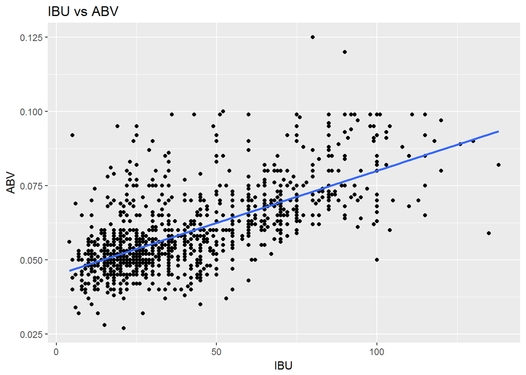

```r
BBPlot <- subset(BB, !is.na(IBU))
BBPlot <- subset(BBPlot, !is.na(ABV))
ggplot(BBPlot, aes(x=IBU, y=ABV)) + geom_point() + geom_smooth(method = lm, se = FALSE) + labs(title = "IBU vs ABV", x = "IBU", y = "ABV")
```